# Vocabulary of Complex Survey Sampling

Lecture 9A

PUBHBIO 6250

## Assumption of a “Random Sample”

- So far in this course we have assumed that individuals in the sample are a **simple random sample** from the target population.
  - Every individual has the same probability of being selected into the sample.
  - simple sample statistics = “best estimates” of population parameters.
    - The sample mean $\bar{X}$ is an **unbiased** estimate for the true population mean $\mu$.
    - $E[\bar{X}] = \mu$
- Without formally stating it, we have also been assuming that the population from which the sample is drawn is **infinite**.
- These assumptions are what let us **make inference** using facts like $\bar{X} \sim N(\mu, \sigma^2/n)$.

## What is Complex Survey Sampling?

- Instead of assuming an **infinite** population, complex survey sampling **assumes the population is finite**.
  - Could write down a finite list of every member of the population (in theory, if not in practice)
- We then **randomly** select a sample from this **finite** list.
  - Key idea: Does **not** have to be a sample where all units have the same probability of selection – may (purposely) be more likely to sample certain units than others
  - Could involve any number of **complex design features**, including:
    - Stratification
    - Clustering
    - Multi-stage sampling
    - Selecting units with probabilities proportional to their size
    - Other features possible

## What’s So Different?

- We can’t use the statistical properties we’ve relied on so far.
  - Must account for the **sampling design** – the procedure by which units were randomly selected.
- We will need **weights** to account for the fact that some units were more likely than others to be sampled.
- If the population is small, we get a **gain in precision** (i.e., **smaller variance**) compared to assuming the population is infinite.
  - Previously: **Infinite** population $\rightarrow$ like **sampling** **with** **replacement**
  - Now: **Finite** population $\rightarrow$ like **sampling** **without** **replacement**
- **Data collected via a complex sampling design require special analysis techniques!**

## Some Key Survey Vocabulary

**Observation Unit** – One (non-overlapping) unit on which a measurement is taken

**Target Population** – The complete collection of observation units that we want to study (about which we want to make inference)

**Sampling Unit** – A unit that can be selected for a sample (might be an observation unit, or might be a collection of observation units, e.g., a household)

**Sampling Frame** – A list of all sampling units in the population (for some sampling designs this might not actually be available)

## Example

The OSU Office of Student Life conducts annual surveys to explore the involvement, engagement, and sense of belonging of students. The 2023 Student Life Survey was administered to a random sample of 4,250 undergraduate students on the Columbus campus (out of a population of 45,725 undergraduates) during January 2023 by emailing a link to an online survey.

- **Observation Unit (or Element)** = OSU undergraduate student
- **Target Population** = All OSU undergraduates on Columbus campus
- **Sampling Unit** = OSU undergraduate student
- **Sampling Frame** = List of all OSU undergraduates on Columbus campus (including their email addresses)

## Exercise

A survey is conducted to find the average weight of cows in Wayne County, Ohio. A list of all farms is available for the county, and 20 farms are selected at random. A sample of 10 cows per farm is then randomly selected, and the weight of each cow is recorded.

- **Observation Unit (or Element)** = One cow
- **Target Population** = All cows in Wayne County
- **Sampling Unit** = One farm
- **Sampling Frame** = List of all farms in Wayne County

## Key Design Feature: Simple Random Sampling

**Simple Random Sampling (SRS)** = every possible subset of $n$ units in the population has the same chance of being in the sample.

- Every unit has **equal probability of selection**
- **Simple random sample with replacement (SRSWR)** – a unit could be selected into the sample more than once.
  - Pick each unit with equal probability, put it back, pick another unit.
- **Simple random sample without replacement (SRSWOR or just SRS)** – a unit can only be selected into the sample once.

In general when survey samplers say “SRS” we mean SRSWOR.

**SRS is usually combined with other features**.

## Key Design Feature: Stratification

**Stratification** = divide population into distinct subgroups called strata, and sample from each stratum independently (singular: stratum, plural: strata)

- Strata must be mutually exclusive (each unit only belongs to 1 stratum)
- Strata must be exhaustive (all units belong to a stratum)
- Strata are often **subgroups of interest** – ensures adequate sample in subgroup
- How much sample comes from each stratum is called the **allocation method**
  - E.g., take 10% of each stratum; take 100 units in each stratum

If units in the same stratum tend to be more similar than randomly selected units across strata, stratifying can **increase precision** (smaller variance) relative to an SRS.

- Ex: measuring health outcomes using birthweight strata (low vs. normal birthweight)

## Key Design Feature: Clustering

**Cluster Sample** = individual units in the population are aggregated into larger sampling units called **clusters**, and a sample of clusters is selected

- Often used when you do not have a full list of individual units in the population, but you do have a list of all clusters in the population
  - Example: Have list of all residences but not names of all residents
- Can reduce costs
- Can cause a **decrease in precision** (larger variance) relative to SRS, because individual observation units within a cluster tend to be similar
- **One-stage cluster sample** – **all** units in selected clusters are selected into the sample
- **Two-stage cluster sample** – **some** units in selected clusters are (randomly) selected into the sample

## Key Design Feature: Multi-Stage Sampling

**Multi-stage Sampling** = select a sample in stages, using smaller and smaller sampling units (clusters) at each stage

Ex: NHANES sampling scheme:

[NHANES Sample Design tutorial](https://wwwn.cdc.gov/nchs/nhanes/tutorials/SampleDesign.aspx)

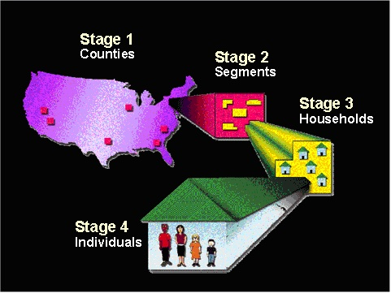

- **Primary Sampling Unit (PSU)** = sampling unit sampled at **first** stage
- **Secondary Sampling Unit (SSU)** = sampling unit sampled at **second** stage
- **Tertiary Sampling Unit (TSU)** = sampling unit sampled at **third** stage
- etc. …

## Key Design Feature: PPS Sampling

**Probability Proportional to Size (PPS) Sampling** = the probability of selection for a unit is directly proportional to a size measure which is known for all units before sampling

- **Not** equal probability of selection for all units!
- Larger units **are more likely** to be sampled
- Can result in a **decrease in precision** (larger variance) relative to SRS
- Often used in early stages of **multi-stage samples**
- Example (NHANES):
  - Stage 1: Sample counties via PPS (size = population size)
  - Stage 2: Sample segments within selected counties via PPS (size = pop. size)
  - Stage 3: Sample households within selected segments via SRS
  - Stage 4: Sample individuals within selected households via SRS

## This Lecture Does Not Cover It All!

This course will not cover all the possible design features!

(See: PUBHBIO 7225 – but even that can’t cover it ALL!)

Additional features commonly used in large-scale surveys (e.g., NHANES) that you may encounter:

- **Certainty units** = units that are selected into a sample with 100% certainty (guaranteed to be in the sample, by design)
- **Systematic sampling** = a method of choosing a sample that takes a list of the sampling units, randomly chooses a starting point, and takes every $k$th unit into the sample
- **Masked Variance Units** = “constructed” clusters that are not the same as the PSUs in the design, but are created to mimic the actual clusters. These are provided with publicly available data instead of the actual PSUs to protect confidentiality.